# Effect of modelling a phenotype as a trait of an individual’s mother on estimating $V_A$

Joel Pick

# Introduction

Maternal effects are common, especially in traits expressed in juveniles (Moore et al 2019). When the traits underlying the maternal effects have a genetic basis (i.e. maternal genetic effects), then the response to selection of these traits is no longer predicted by $V_A$ alone, with the ‘total’ $V_A$ being calculated as
$$V_A + 3/2 COV_{A,Mg} + 1/2 V_{Mg}$$
(Willham, 1972).

Previous work has shown that not accounting for these maternal effects can bias estimates of $V_A$ (Clements et al 2001), including in empirical estimates of wild populations (e.g. Wilson et al 2005 Soay Sheep, Kruuk and Hadfield 2007 Red Deer), and so in turn the total evolutionary potential of a trait. We do not know the systematically to what extent estimates of $V_A$ are affected, or how pedigree structure influences this (need to look more at Clements et al 2001).

Sometimes juvenile traits (e.g. body size or survival) are considered to be a trait of the mother (e.g. Morrissey et al 2012 - Red Deer - survival). The consequences of estimating $V_A$ in this manner, and so the impact on estimating total $V_A$ and selection response, have not been explored.

Here we investigate 3 questions:

- How estimation of total $V_A$ is affected by whether/how maternal effects are modelled
- How estimation of total $V_A$ is affected when juvenile traits are considered a phenotype of the mother
- How the above are affected by pedigree structure (relatedness and depth)

# Methods

## Simulations

Individual based simulations using squidPed

Discrete generations, Random mating, Fixed fecundity (4 offspring per individual), Fixed population size, Fixed equal sex ratio. Juvenile survival = 0.5

Two mating systems:

- full sib families (each female mates with one male and each male mates with one female)
- half sib families (paternity of offspring random assigned across all males)

Two pedigree depths:

- shallow - 2 gens with 1000 individuals per generation
- deep - 20 gens with 100 individuals per generation

## Relatedness structure in real pedigrees

How much does relatedness within mothers vary in natural pedigrees?

Used 17 of 19 pedigrees from Bonnet et al 2022 (through backtransforming inverse A matrices), and two additional pedigrees (Dalmeny Blue tits and Lundy House Sparrows), calculated the average relatedness of offspring within each mother.

Relatedness should vary between 0.25 and 0.5, but can be higher, I think because of inbreeding.

Broadly the populations can be split into 3 groups - those that have mostly full sibs:

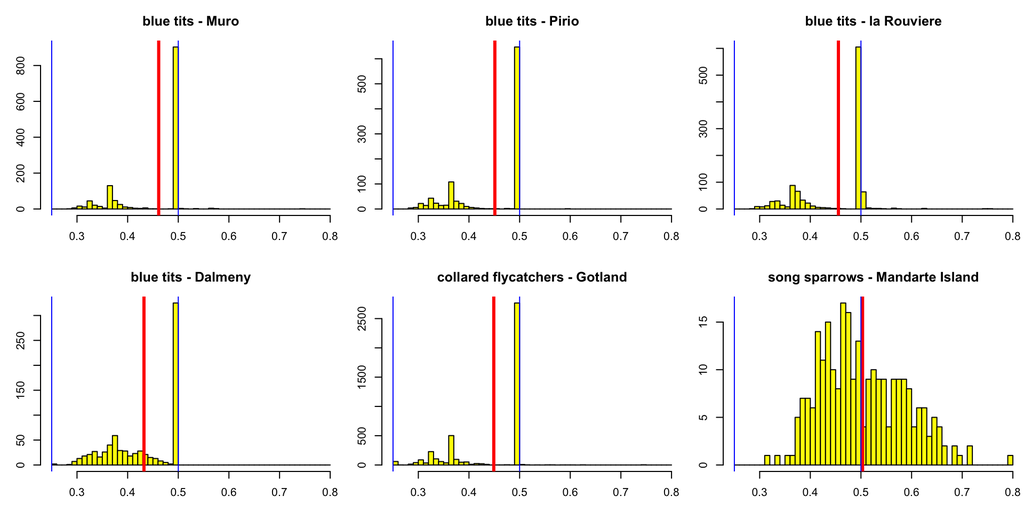

The blue tit and collared flycatcher populations are remarkably similar, and have other small peaks, which likely correspond to females switching partners between breeding attempts. The Dalmeny blue tits are more smoothed, likely representing the use of genetic rather than social pedigree.

The song sparrows have a very strange distribution - perhaps they are super inbred? But this seems quite extreme?!

Then species where there is both a peak at 0.5 and 0.25, and a peak in-between.

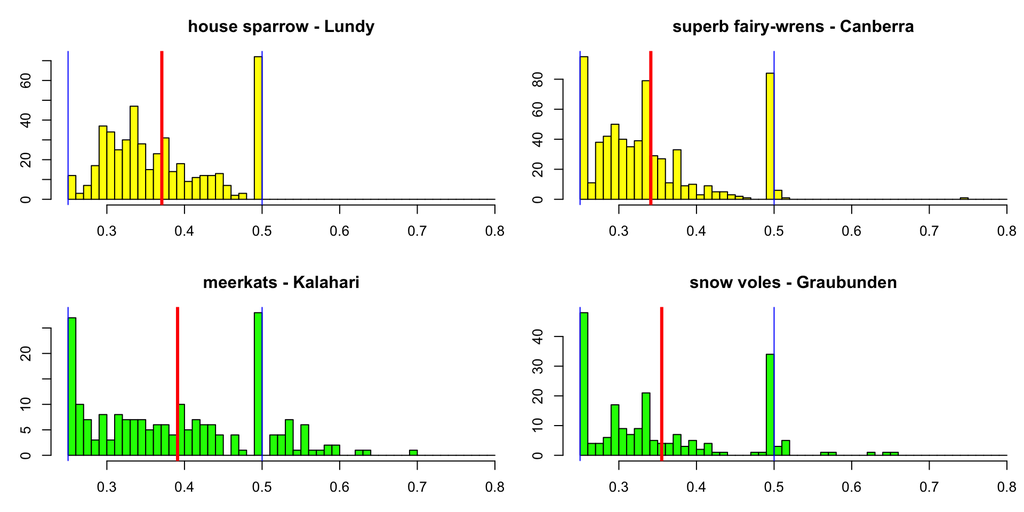

And then species where there is a clear peak at 0.25, with a bit of variation, indicating that most offspring are half-sibs.

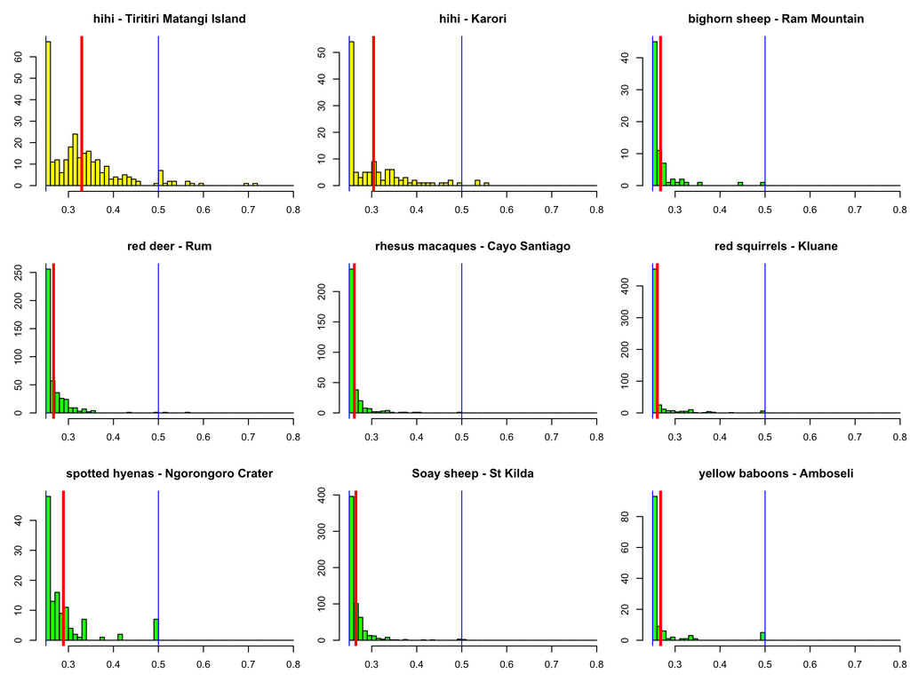

Overall it seems that simulating full-sib and half-sib structure are reasonable representations of natural populations. Should maybe consider an intermediate structure? Have some level of EPP?

## Simulated scenarios

1. Direct genetic effects only
2. Maternal environment only
3. Maternal genetic only
4. Direct genetic and maternal environment
5. Maternal genetic and maternal environment
6. Direct and maternal genetic, no covariance
7. Direct and maternal genetic, positive covariance
8. Direct and maternal genetic, negative covariance
9. Direct and maternal genetic, no covariance and maternal environment
10. Direct and maternal genetic, positive covariance and maternal environment
11. Direct and maternal genetic, negative covariance and maternal environment

Phenotypes simulated across the simulated pedigrees using squidSim package. Phenotypes simulated to have 0 mean and unit variance. Set the total VA to be constant? Or vary across the different scenarios?

## Models

Assuming trait of juvenile

1. $V_A$
2. $V_A$ and $V_{Me}$
3. $V_A$ and $V_{Mg}$
4. $V_A$, $V_{Me}$ and $V_{Mg}$
5. $V_A$, $V_{Me}$, $V_{Mg}$ and $COV_{A,Mg}$

Assuming trait of Mother

6. $V_A$
7. $V_A$ and $V_{PE}$
8. $V_A$ of mean offspring measures

## Model comparison

Will compare different variance components in the different models, especially $V_A$. Will also compare the estimated total $V_A$ - although some models may be biased in the estimation of specific components, it maybe that they predict response to selection equally well

#Results

## Scenario A - Direct genetic effects only

Expectations - Models 1-4 will all estimate $V_A$ properly - Model 5 will estimate 1/4 with half sib and 1/2 with full sib - Model 6 will estimate 1/4 with half sib with both, as maternal ID will capture additional 1/4 $V_A$ - Model 7 will estimate 1/4 with both

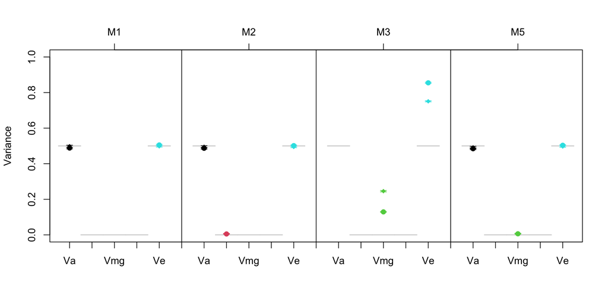

## Scenario C - Maternal genetic effects only

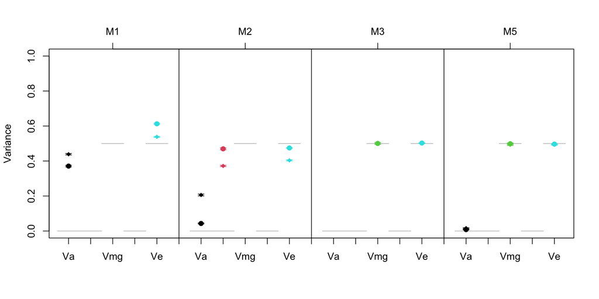

## Scenario C - Both Uncorrelated

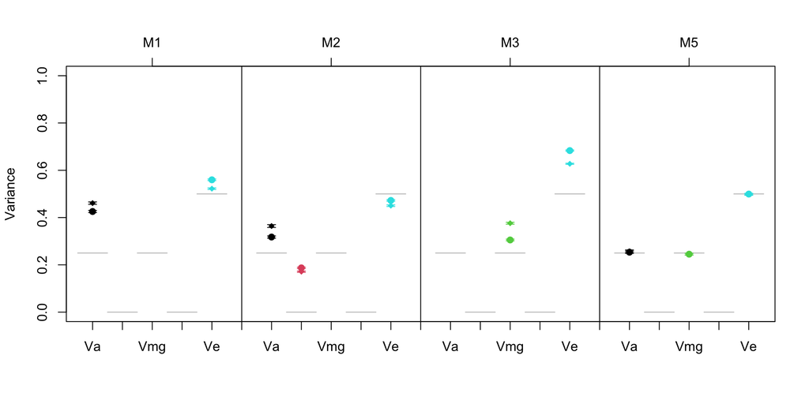

## Scenario D - Both Positively Correlated

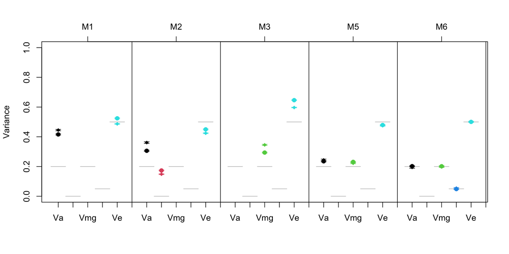

```
##              A         Me         Mg      cov_AMg         E
## [1,] 0.3845502         NA         NA           NA 0.5118258
## [2,] 0.3788723 0.02438599         NA           NA 0.4943054
## [3,]        NA         NA 0.11541877           NA 0.7778631
## [4,] 0.3766228         NA 0.01733287           NA 0.5049127
## [5,] 0.3791248         NA 0.01830056 -0.002137995 0.5034278
```

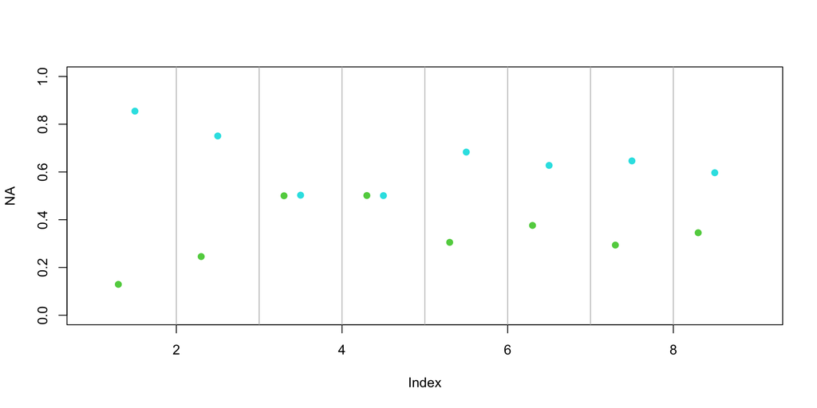

## Comparing evolutionary potential

When only direct genetic effects, models assuming trait of mother are highly biased.

The bias is much smaller when both direct and maternal genetic effects are present.

Interestingly the models with fill sibs are less bad based on total va

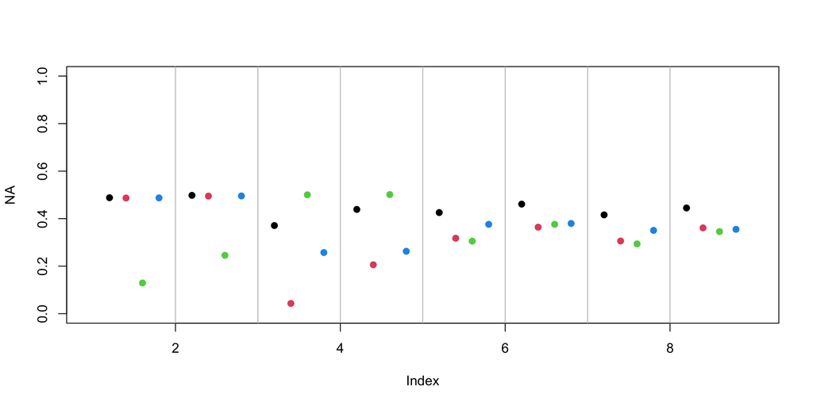